# Normalization performance report

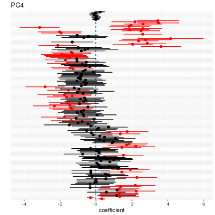

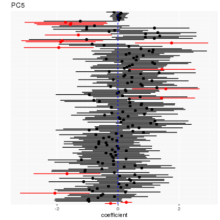

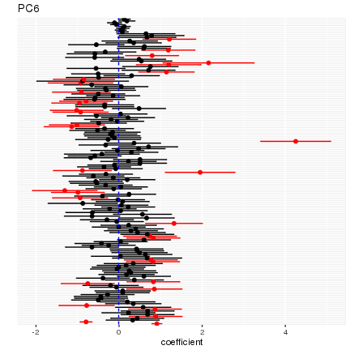

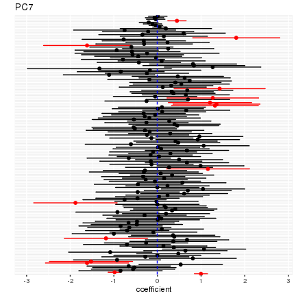

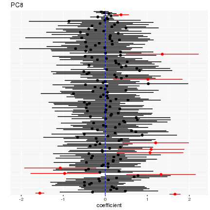

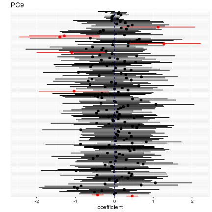

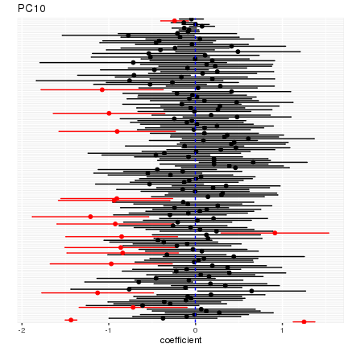

| batch.variable | batch.value | principal.component | test | p.value | estimate | lower | upper |
| --- | --- | --- | --- | --- | --- | --- | --- |
| Slide |  | PC1 | F-test | 6.76e-216 | 14.710 |  |  |
| Slide | 3999932009 | PC1 | t-test | 2.06e-10 | 4.441 | 2.8879 | 5.9950 |
| Slide | 3999932066 | PC1 | t-test | 6.44e-41 | 9.138 | 7.6542 | 10.6219 |
| Slide | 3999932067 | PC1 | t-test | 3.46e-13 | 5.124 | 3.5612 | 6.6870 |
| Slide | 3999932069 | PC1 | t-test | 2.64e-13 | 4.880 | 3.3987 | 6.3603 |
| Slide | 3999932070 | PC1 | t-test | 1.63e-27 | 8.050 | 6.4231 | 9.6767 |
| Slide | 3999932082 | PC1 | t-test | 1.75e-05 | 2.985 | 1.4339 | 4.5354 |
| Slide | 3999932083 | PC1 | t-test | 2.32e-11 | 5.490 | 3.6647 | 7.3147 |
| Slide | 3999932098 | PC1 | t-test | 4.24e-27 | 8.420 | 6.7038 | 10.1357 |
| Slide | 3999932104 | PC1 | t-test | 1.29e-33 | 8.184 | 6.7032 | 9.6652 |
| Slide | 3999932111 | PC1 | t-test | 4.74e-57 | 12.175 | 10.5309 | 13.8195 |
| Slide | 3999932114 | PC1 | t-test | 4.39e-04 | 2.332 | 0.8504 | 3.8126 |
| Slide | 3999932120 | PC1 | t-test | 1.16e-37 | 9.193 | 7.6307 | 10.7560 |
| Slide | 3999932122 | PC1 | t-test | 1.35e-44 | 11.128 | 9.4051 | 12.8516 |
| Slide | 3999932124 | PC1 | t-test | 3.26e-09 | 3.986 | 2.4872 | 5.4849 |
| Slide | 3999932125 | PC1 | t-test | 3.16e-17 | 5.686 | 4.1958 | 7.1771 |
| Slide | 3999932126 | PC1 | t-test | 2.38e-07 | 3.452 | 1.9632 | 4.9400 |
| Slide | 3999932132 | PC1 | t-test | 5.42e-81 | 13.993 | 12.4424 | 15.5439 |
| Slide | 3999941088 | PC1 | t-test | 1.68e-11 | 4.701 | 3.1492 | 6.2521 |
| Slide | 3999941089 | PC1 | t-test | 1.15e-25 | 7.437 | 5.8753 | 8.9991 |
| Slide | 3999941122 | PC1 | t-test | 2.39e-14 | 5.121 | 3.6324 | 6.6095 |
| Slide | 3999941136 | PC1 | t-test | 1.98e-04 | 2.691 | 1.0763 | 4.3057 |
| Slide | 3999941137 | PC1 | t-test | 2.24e-04 | 3.023 | 1.1938 | 4.8529 |
| Slide | 3999941138 | PC1 | t-test | 3.91e-12 | 5.125 | 3.4849 | 6.7645 |
| Slide | 10003886192 | PC1 | t-test | 3.40e-19 | 6.061 | 4.5652 | 7.5560 |
| Slide | 10003886212 | PC1 | t-test | 7.18e-28 | 7.410 | 5.9229 | 8.8964 |
| Slide | 10003886214 | PC1 | t-test | 1.02e-16 | 5.571 | 4.0857 | 7.0564 |
| Slide | 10003886229 | PC1 | t-test | 2.85e-14 | 5.114 | 3.6230 | 6.6050 |
| Slide | 10003886230 | PC1 | t-test | 1.59e-28 | 7.615 | 6.1066 | 9.1240 |
| Slide | 10003886231 | PC1 | t-test | 7.56e-20 | 6.135 | 4.6496 | 7.6213 |

[output cut: 246 more lines]